# Preppin Data: 2019 Week 4

David Jackson

11/2/2021

# San Antonio Spurs

- Hi Points = Most points scored by a single player during the game
- Hi Rebounds = Most times a player has recovered possession * after a missed shot
- Hi Assists = Most times a player has passed the ball to another player who then scored.

We have given you data just about Carl’s favourite team, the San Antonio Spurs. You will obviously need to clean-up the data, but can then use some other functions in Prep Builder to help you answer the following questions.

1. In games won by the Spurs, which player most often scores the most points?
2. In games lost by the Spurs, which player most often scores the most points?
3. What combination of players scores the most points, rebounds and assists the most frequently?
4. Which player is the second most frequent at gaining the most assists in a game?
5. With the answer to Q4, where do all these games happen: Home or Away?
6. Which player scored the most points in games in October 2018 the most frequently?

## Requirements:

Import the file Fix some date issues! Split the “Hi-” categories up so player and value is separate Determine whether each game was played by the Spurs: Home or Away Determine whether the Spurs won or lost each game Get rid of unrequired columns

### Read In Data and Example Output

### NBA Data Cleaning

#### Pull out Player Name and Points from HI Point Column

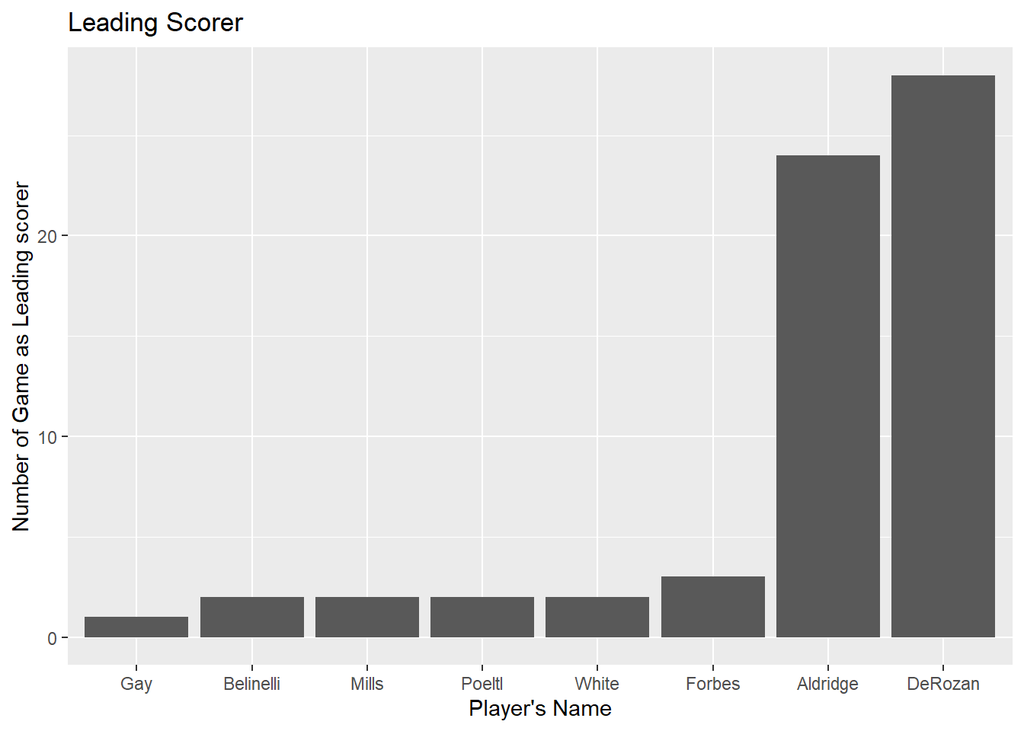

#### Pull out Player Name and Points from HI Rebounds Column

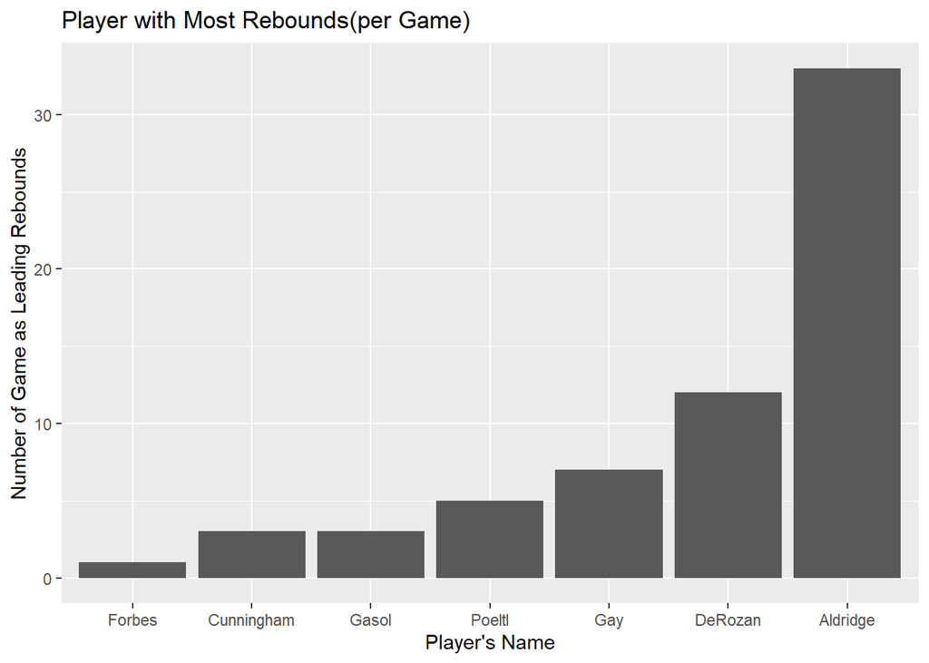

#### Pull out Player Name and Points from HI Assist Column

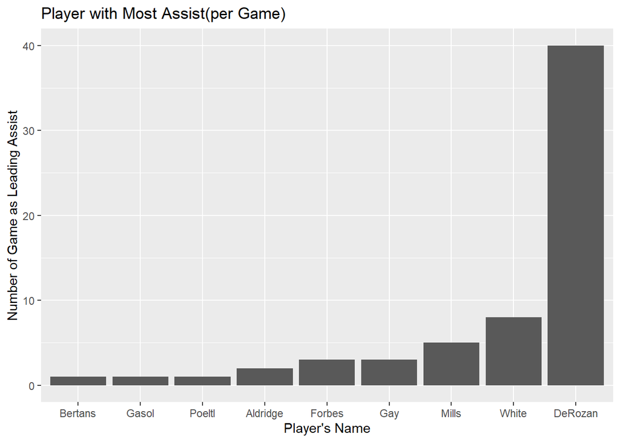

## Dlookr Table Summary

| variables | min | Q1 | mean | median | Q3 | max | zero | minus | outlier |
| --- | --- | --- | --- | --- | --- | --- | --- | --- | --- |
| hi_assist_value | 4 | 5 | 6.796875 | 7 | 8 | 14 | 0 | 0 | 1 |
| hi_rebounds_value | 5 | 9 | 10.718750 | 10 | 12 | 19 | 0 | 0 | 3 |
| hi_points_value | 14 | 23 | 26.453125 | 26 | 30 | 56 | 0 | 0 | 1 |

### Count the number of Wins/Losses by Opponent

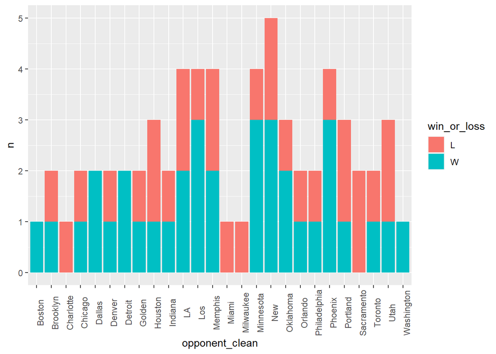